# This or That?

Roberta Rocca

23/04/2018

Analysis of data on crosslinguistic study on semantic preferences in demonstratives use. Data preprocessing performed separately for each dataset. Markdowns available in the **Preprocessing** subfolder.

Run: Sys.setlocale(category = “LC_ALL”, locale = “da_dk.utf-8”) Sys.setlocale(category = “LC_MESSAGES”, locale = “da_dk.utf-8”) For a correct visualization of the Danish characters

### Settings

Set plot parameters and Danish encoding

```
## [1] "da_dk.utf-8/da_dk.utf-8/da_dk.utf-8/C/da_dk.utf-8/C"
```

```
## [1] "da_dk.utf-8"
```

### Analysis

Includes logistic regression using categorical predictors per each dataset, as well as cumulative analysis. Also includes parametrized version using animacy, harmfulness and size scores. Loading the dataset with information on experimental words

```r
library(readr)
library(lme4)
library(dplyr)

# Read in the dataframes with scores for experimental words along each dimension
exp1 <- read.table('exp1.txt', sep = '\t', header = TRUE)
exp2 <- read.table('exp2.txt', sep = '\t', header = TRUE)
exp1 <- exp1[, c(1:(ncol(exp1) - 3))]
exp2 <- exp2[, c(1:(ncol(exp2) - 3))]

head(exp1)
```

```
##     Noun AnimScore SizeScore HarmScore
## 1    bee         4         1         5
## 2  bench         1         5         1
## 3   bomb         1         4         5
## 4   bull         5         5         5
## 5 burner         1         1         5
## 6  camel         5         5         1
```

```r
head(exp2)
```

```
##       Noun AnimScore SizeScore HarmScore
## 1   school  1.000000  4.736782  1.942828
## 2 landmine  1.138953  3.273840  3.184483
## 3    horse  3.436670  4.839318  2.448969
## 4    apple  1.578454  1.171975  1.280316
## 5    tiger  3.607177  4.088695  3.315896
## 6   bomber  1.952767  5.675781  4.209497
```

Load the frequency data

```r
# BNC
freq_bnc <- read_tsv('freq_bnc.txt')
# Danish
freq_dk <- read_tsv('freq_dk.txt')
freq_dk$Freq <- freq_dk$Freq / 2570.805
#Italian
freq_it <- read_tsv('freq_it.txt')
freq_it$Freq <- freq_it$Freq / 5864.496
# Merge all the frequency data in a single dataset.
freq <- rbind(freq_bnc[, 2:3], freq_dk)
freq <- rbind(freq, freq_it)
```

Read in the data from the experiment **Please note** that there might be issues with the encoding of Danish characters. Check how they’re read in, and change code accordingly.

```r
# Load experiment 1
data_EN <- read.table('EN_1.txt', sep = '\t', header = TRUE)
data_IT <- read.table('IT_1.txt', sep = '\t', header = TRUE)
data_DK <- read.table('DK_1.txt', sep = '\t', header = TRUE)

# Load experiment 2
data_IT2 <- read.table('IT_2.txt', sep = '\t', header = TRUE)
data_DK2 <- read.table('DK_2.txt', sep = '\t', header = TRUE)

# Replace misprinted Danish characters
data_DK$Noun <- plyr::mapvalues(data_DK$Noun, from=c('n.l', 'sm.kage', 'f.rekylling', 'g.s', 'hy.ne', 'f.ngsel', 'r.dhals', 's.be', 'b.nk', 'm.nt'), to=c('n??l', 'sm??kage', 'f??rekylling', 'g??s', 'hy??ne', 'f??ngsel', 'r??dhals', 's??be', 'b??nk', 'm??nt'))
data_DK2$Noun <- plyr::mapvalues(data_DK2$Noun, from=c('skovfl.t', 'r.dyr', 'egetr.', 'X.ble'),to=c('skovfl??t', 'r??dyr', 'egetr??', '??ble'))

# list of italian words for exp2
it_words_2 <- c('tigre', 'cobra', 'coccodrillo', 'cinghiale', 'zanzara', 'medusa', 'tarantola', 'zecca','giraffa', 'cavallo', 'delfino', 'cerbiatto', 'coniglio', 'farfalla', 'scoiattolo', 'passero','meteorite', 'valanga', 'vulcano', 'bombardiere', 'mina', 'veleno', 'proiettile', 'coltello','scuola', 'quercia', 'contrabbasso', 'cupola', 'tazza', 'scarpa', 'cucchiaio', 'mela')
# list of Danish words for exp2
dk_words_2 <- c('tiger', 'kobra', 'krokodille', 'vildsvin', 'myg', 'giftgople', 'fugleedderkop', 'skovfl??t','giraf', 'hest', 'delfin', 'r??dyr', 'kanin', 'sommerfugl', 'egern', 'spurv','meteor', 'lavine', 'vulkan', 'bombefly', 'landmine', 'gift', 'patron', 'kniv','skole', 'egetr??', 'kontrabas', 'kuppel', 'krus', 'sko', 'ske', '??ble')
# List of english words for exp 2

exp_words_2 <- c('tiger', 'cobra', 'crocodile', 'boar', 'mosquito', 'jellyfish', 'tarantula', 'tick','giraffe', 'horse', 'dolphin','fawn', 'rabbit', 'butterfly','squirrel', 'sparrow', 'meteorite', 'avalanche', 'volcano', 'bomber', 'landmine', 'poison', 'bullet', 'knife',
                 'school', 'oak', 'bass', 'dome', 'mug', 'shoe', 'spoon', 'apple')


# Replace nouns in IT ad DK with English equivalents
data_IT$NounEng <- plyr::mapvalues(data_IT$Noun, from=unique(as.character(data_IT$Noun)), to= unique(as.character(data_EN$Noun)))
data_DK$NounEng <- plyr::mapvalues(data_DK$Noun, from=unique(as.character(data_DK$Noun)), to=unique(as.character(data_EN$Noun)))

# Same for experiment 2
data_IT2$NounEng <- plyr::mapvalues(data_IT2$Noun, from=it_words_2, to = exp_words_2)
data_DK2$NounEng <- plyr::mapvalues(data_DK2$Noun, from=dk_words_2, to = exp_words_2)

# Add Lang info to the dataset (for merging)
data_IT$Lang <- 'IT'
data_DK$Lang <- 'DK'
data_EN$Lang <- 'EN'
data_IT2$Lang <- 'IT'
data_DK2$Lang <- 'DK'

# Rename
colnames(data_EN)[9] <- 'NounEng'
data_EN$Noun <- data_EN$NounEng
```

Including info on experimental variables and merging all in single dataset

```r
# Merge dataset from experiment 1 with scores and category
data_EN <- merge(data_EN, exp1, by.x = 'NounEng', by.y = 'Noun')
data_IT <-merge(data_IT, exp1, by.x = 'NounEng', by.y = 'Noun')
data_DK <-merge(data_DK, exp1, by.x = 'NounEng', by.y = 'Noun')

# Merge Danish and English data
data <- rbind(data_EN[, -c(7,8)], data_DK)
# Add a column which is there in the Italian dataset
data$Incorrect <- 'Correct'
# Merge with Italian
data <- rbind(data, data_IT[, -c(10)])
# Add info on number of experiment
data$ExpNr <- 1

# Now merge data for exp2
data_IT2 <-merge(data_IT2, exp2, by.x = 'NounEng', by.y = 'Noun')
data_DK2 <-merge(data_DK2, exp2, by.x = 'NounEng', by.y = 'Noun')
data2 <- rbind(data_IT2, data_DK2)
data2$ExpNr <- 2
data2$Incorrect <- 'Correct'

# Merge data from the two experiments
data_all <- rbind(data, data2)
data_all$Noun <- plyr::mapvalues(data_all$Noun, from=c('b??nk', 'm??nt', 'sm??kage', 'f??rekylling',  'g??s', 'hy??ne', 'f??ngsel', 'n??l', 'r??dhals', 's??be', '??ble', 'r??dyr', 'egetr??', 'skovfl??t'), to = c('bænk', 'mønt', 'småkage', 'fårekylling', 'gås', 'hyæne', 'fængsel', 'nål', 'rødhals', 'sæbe', 'æble', 'rådyr', 'egetræ', 'skovflåt'))
data_all <- merge(data_all, freq, by.x = 'Noun', by.y = 'Word')

# Check small error
data_all$Animate[data_all$NounEn %in% c('spider', 'kitten')] <- 'Animate'

# Just because it's handy: also keep a copy of separate datasets
data_IT <- subset(data_all, Lang == 'IT' & ExpNr == 1)
data_DK <- subset(data_all, Lang == 'DK' & ExpNr == 1)
data_EN <- subset(data_all, Lang == 'EN' & ExpNr == 1)
data_IT2 <- subset(data_all, Lang == 'IT' & ExpNr == 2)
data_DK2 <- subset(data_all, Lang == 'DK' & ExpNr == 2)
```

Proportion of proximal demonstratives across experimental variables for each of the languages and experiments

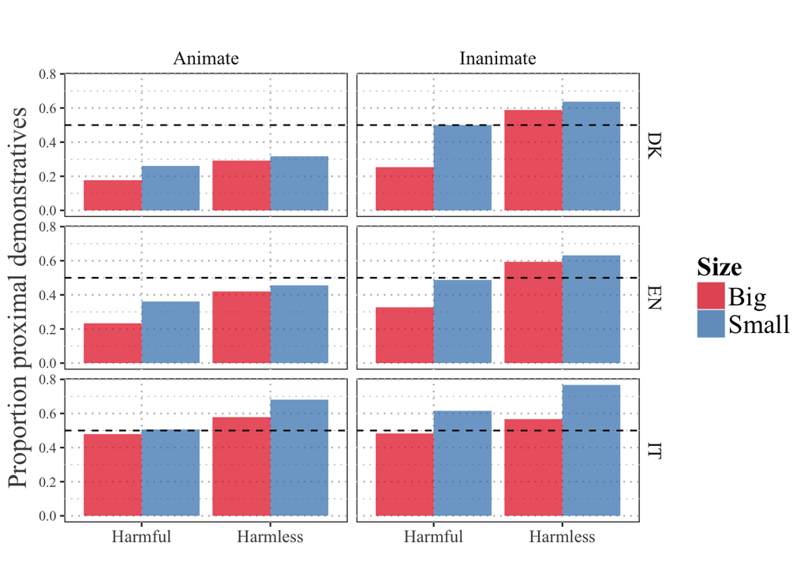

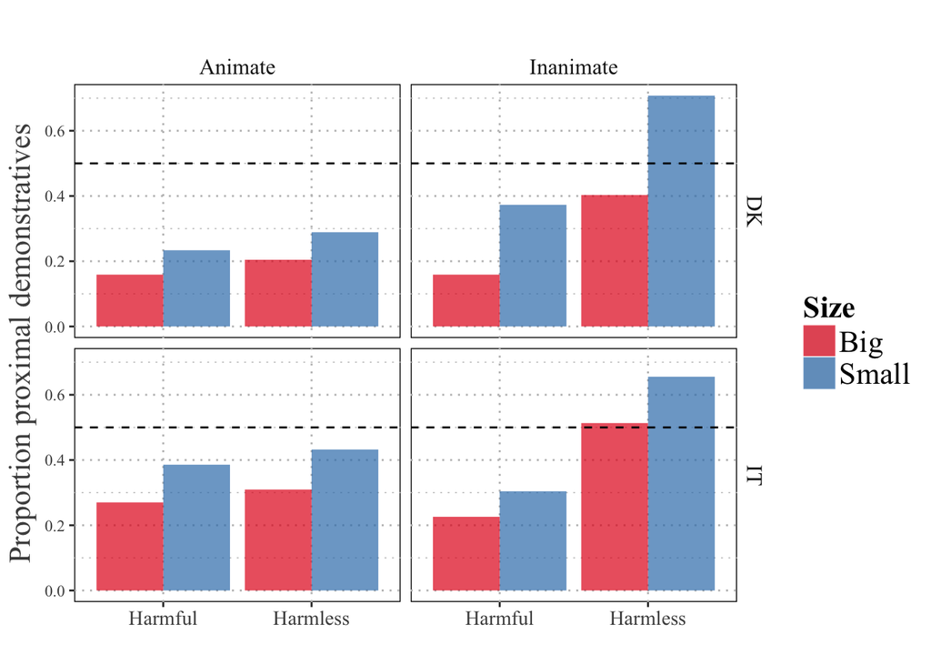

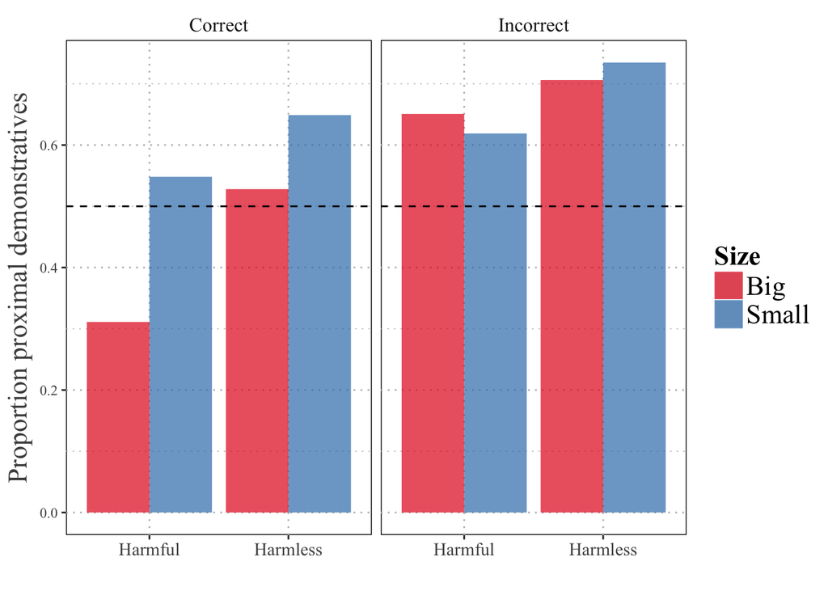

Stats: mixed-effects logistic regression for each of the experiments. Same model used for all languages, fixed effects structure including all the experimental factors and full interaction structure. Random effects structure include random intercept for ID. More complicated random effects structure fitted in the overall model.

#### Experiment 1

```r
# Model all data, add fixed effect of language and interactions
model_1 <- glmer(data = subset(data_all, !(ExpNr == 2)),
                 factor(Demonstrative) ~ Animate * Size * Harm * Lang + (1|ID),
                 family = 'binomial',
                 glmerControl(optimizer="bobyqa", optCtrl = list(maxfun = 100000)))
summary(model_1)
```

```
## Generalized linear mixed model fit by maximum likelihood (Laplace
##   Approximation) [glmerMod]
##  Family: binomial  ( logit )
## Formula: factor(Demonstrative) ~ Animate * Size * Harm * Lang + (1 | ID)
##    Data: subset(data_all, !(ExpNr == 2))
## Control:
## glmerControl(optimizer = "bobyqa", optCtrl = list(maxfun = 1e+05))
##
##      AIC      BIC   logLik deviance df.resid
##  14304.8  14488.8  -7127.4  14254.8    11605
##
## Scaled residuals:
##     Min      1Q  Median      3Q     Max
## -4.5843 -0.7773 -0.3226  0.8039  4.3465
##
## Random effects:
##  Groups Name        Variance Std.Dev.
##  ID     (Intercept) 0.6232   0.7894
## Number of obs: 11630, groups:  ID, 364
##
## Fixed effects:
##                                                   Estimate Std. Error
## (Intercept)                                      -1.747056   0.159057
## AnimateNon_Animate                                0.515903   0.183197
## SizeSmall                                         0.559875   0.182501
## HarmHarmless                                      0.737091   0.179961
## LangEN                                            0.434679   0.204256
## LangIT                                            1.656787   0.196727
## AnimateNon_Animate:SizeSmall                      0.678815   0.243236
## AnimateNon_Animate:HarmHarmless                   0.911338   0.242168
## SizeSmall:HarmHarmless                           -0.105292   0.241971
## AnimateNon_Animate:LangEN                        -0.002392   0.233975
## AnimateNon_Animate:LangIT                        -0.498566   0.225396
## SizeSmall:LangEN                                  0.122263   0.232552
## SizeSmall:LangIT                                 -0.256447   0.224929
## HarmHarmless:LangEN                               0.217394   0.229614
## HarmHarmless:LangIT                              -0.284583   0.223138
## AnimateNon_Animate:SizeSmall:HarmHarmless        -0.810859   0.329121
## AnimateNon_Animate:SizeSmall:LangEN              -0.617884   0.313059
## AnimateNon_Animate:SizeSmall:LangIT              -0.431694   0.306623
```

[output cut: 18 more lines]

```
## SizeSmall:LangEN                                   0.526 0.599065
## SizeSmall:LangIT                                  -1.140 0.254235
## HarmHarmless:LangEN                                0.947 0.343750
## HarmHarmless:LangIT                               -1.275 0.202180
## AnimateNon_Animate:SizeSmall:HarmHarmless         -2.464 0.013751 *
## AnimateNon_Animate:SizeSmall:LangEN               -1.974 0.048416 *
## AnimateNon_Animate:SizeSmall:LangIT               -1.408 0.159161
## AnimateNon_Animate:HarmHarmless:LangEN            -2.066 0.038787 *
## AnimateNon_Animate:HarmHarmless:LangIT            -3.212 0.001318 **
## SizeSmall:HarmHarmless:LangEN                     -1.328 0.184038
## SizeSmall:HarmHarmless:LangIT                      0.972 0.330844
## AnimateNon_Animate:SizeSmall:HarmHarmless:LangEN   1.785 0.074308 .
## AnimateNon_Animate:SizeSmall:HarmHarmless:LangIT   2.572 0.010118 *
## ---
## Signif. codes:  0 '***' 0.001 '**' 0.01 '*' 0.05 '.' 0.1 ' ' 1
```

Zoom: Italian data

```r
it_log1 <- glmer(data = data_IT,
                 factor(Demonstrative) ~ Animate * Size * Harm + (1|ID),
                 family = 'binomial',
                 glmerControl(optimizer="bobyqa", optCtrl = list(maxfun = 100000)))
summary(it_log1)
```

```
## Generalized linear mixed model fit by maximum likelihood (Laplace
##   Approximation) [glmerMod]
##  Family: binomial  ( logit )
## Formula: factor(Demonstrative) ~ Animate * Size * Harm + (1 | ID)
##    Data: data_IT
## Control:
## glmerControl(optimizer = "bobyqa", optCtrl = list(maxfun = 1e+05))
##
##      AIC      BIC   logLik deviance df.resid
##   5283.8   5340.9  -2632.9   5265.8     4180
##
## Scaled residuals:
##     Min      1Q  Median      3Q     Max
## -3.3992 -0.8897  0.4870  0.7533  2.3095
##
## Random effects:
##  Groups Name        Variance Std.Dev.
##  ID     (Intercept) 0.5691   0.7544
## Number of obs: 4189, groups:  ID, 131
##
## Fixed effects:
##                                           Estimate Std. Error z value
## (Intercept)                               -0.09045    0.11388  -0.794
## AnimateNon_Animate                         0.01727    0.13118   0.132
## SizeSmall                                  0.30223    0.13137   2.301
## HarmHarmless                               0.45073    0.13188   3.418
## AnimateNon_Animate:SizeSmall               0.24621    0.18654   1.320
## AnimateNon_Animate:HarmHarmless           -0.06993    0.18623  -0.376
## SizeSmall:HarmHarmless                     0.19275    0.18904   1.020
## AnimateNon_Animate:SizeSmall:HarmHarmless  0.28544    0.27131   1.052
##                                           Pr(>|z|)
## (Intercept)                               0.427027
## AnimateNon_Animate                        0.895252
## SizeSmall                                 0.021414 *
## HarmHarmless                              0.000632 ***
## AnimateNon_Animate:SizeSmall              0.186869
## AnimateNon_Animate:HarmHarmless           0.707280
## SizeSmall:HarmHarmless                    0.307903
## AnimateNon_Animate:SizeSmall:HarmHarmless 0.292753
## ---
## Signif. codes:  0 '***' 0.001 '**' 0.01 '*' 0.05 '.' 0.1 ' ' 1
##
## Correlation of Fixed Effects:
##             (Intr) AnmN_A SzSmll HrmHrm AnN_A:SS AN_A:H SzS:HH
## AnmtNn_Anmt -0.576
## SizeSmall   -0.575  0.499
## HarmHarmlss -0.573  0.497  0.498
## AnmtNn_A:SS  0.405 -0.703 -0.703 -0.349
## AnmtNn_A:HH  0.406 -0.704 -0.352 -0.707  0.495
## SzSmll:HrmH  0.399 -0.347 -0.694 -0.696  0.489    0.493
## AnN_A:SS:HH -0.279  0.483  0.484  0.486 -0.687   -0.686 -0.696
```

Compare previous model for Italian with one taking into account the soundness of the coupling between noun and distal demonstratives

```r
it_corr <-glmer(data = data_IT,
                factor(Demonstrative) ~ Animate * Size * Harm + Incorrect + Incorrect:Animate + Incorrect:Harm + Incorrect:Size + (1|ID),
                family = 'binomial',
                glmerControl(optimizer="bobyqa", optCtrl = list(maxfun = 100000)))

# Compare the model with the previous one
anova(it_log1, it_corr)
```

```
## Data: data_IT
## Models:
## it_log1: factor(Demonstrative) ~ Animate * Size * Harm + (1 | ID)
## it_corr: factor(Demonstrative) ~ Animate * Size * Harm + Incorrect + Incorrect:Animate +
## it_corr:     Incorrect:Harm + Incorrect:Size + (1 | ID)
##         Df    AIC    BIC  logLik deviance  Chisq Chi Df Pr(>Chisq)
## it_log1  9 5283.8 5340.9 -2632.9   5265.8
## it_corr 13 5110.0 5192.4 -2542.0   5084.0 181.79      4  < 2.2e-16 ***
## ---
## Signif. codes:  0 '***' 0.001 '**' 0.01 '*' 0.05 '.' 0.1 ' ' 1
```

```r
# Visualize result of the model
summary(it_corr)
```

```
## Generalized linear mixed model fit by maximum likelihood (Laplace
##   Approximation) [glmerMod]
##  Family: binomial  ( logit )
## Formula:
## factor(Demonstrative) ~ Animate * Size * Harm + Incorrect + Incorrect:Animate +
##     Incorrect:Harm + Incorrect:Size + (1 | ID)
##    Data: data_IT
## Control:
## glmerControl(optimizer = "bobyqa", optCtrl = list(maxfun = 1e+05))
##
##      AIC      BIC   logLik deviance df.resid
##   5110.0   5192.4  -2542.0   5084.0     4176
##
## Scaled residuals:
##     Min      1Q  Median      3Q     Max
## -3.0865 -0.8861  0.4271  0.7213  3.5482
##
## Random effects:
##  Groups Name        Variance Std.Dev.
##  ID     (Intercept) 0.6363   0.7977
## Number of obs: 4189, groups:  ID, 131
##
## Fixed effects:
##                                           Estimate Std. Error z value
## (Intercept)                               -0.78271    0.14097  -5.552
## AnimateNon_Animate                        -0.05559    0.16236  -0.342
## SizeSmall                                  0.71675    0.15927   4.500
## HarmHarmless                               0.90615    0.15240   5.946
## IncorrectIncorrect                         1.36607    0.14485   9.431
## AnimateNon_Animate:SizeSmall               0.43679    0.19789   2.207
## AnimateNon_Animate:HarmHarmless           -0.03006    0.19991  -0.150
## SizeSmall:HarmHarmless                    -0.21553    0.24310  -0.887
## AnimateNon_Animate:IncorrectIncorrect      0.14549    0.16626   0.875
## HarmHarmless:IncorrectIncorrect           -0.32657    0.17577  -1.858
## SizeSmall:IncorrectIncorrect              -0.79793    0.16692  -4.780
## AnimateNon_Animate:SizeSmall:HarmHarmless  0.08987    0.31680   0.284
##                                           Pr(>|z|)
## (Intercept)                               2.82e-08 ***
## AnimateNon_Animate                          0.7321
## SizeSmall                                 6.79e-06 ***
```

[output cut: 22 more lines]

```
## HrmHrmls:II  0.199  0.111 -0.092 -0.353 -0.377 -0.091   -0.051 -0.444
## SzSmll:IncI  0.264  0.049 -0.526 -0.185 -0.499  0.106   -0.025 -0.200
## AnN_A:SS:HH -0.285  0.611  0.331  0.366  0.140 -0.662   -0.706 -0.714
##             AN_A:I HrH:II SzS:II
## AnmtNn_Anmt
## SizeSmall
## HarmHarmlss
## IncrrctIncr
## AnmtNn_A:SS
## AnmtNn_A:HH
## SzSmll:HrmH
## AnmtNn_A:II
## HrmHrmls:II -0.211
## SzSmll:IncI -0.094  0.161
## AnN_A:SS:HH -0.458  0.243  0.068
```

Model for experiment 2

```r
# Model all data, add fixed effect of language and interactions
model_2 <- glmer(data = subset(data_all, !(ExpNr == 1)),
                 factor(Demonstrative) ~ Animate * Size * Harm * Lang + (1|ID),
                 family = 'binomial',
                 glmerControl(optimizer="bobyqa", optCtrl = list(maxfun = 100000)))

summary(model_2)
```

```
## Generalized linear mixed model fit by maximum likelihood (Laplace
##   Approximation) [glmerMod]
##  Family: binomial  ( logit )
## Formula: factor(Demonstrative) ~ Animate * Size * Harm * Lang + (1 | ID)
##    Data: subset(data_all, !(ExpNr == 1))
## Control:
## glmerControl(optimizer = "bobyqa", optCtrl = list(maxfun = 1e+05))
##
##      AIC      BIC   logLik deviance df.resid
##  19687.1  19819.2  -9826.5  19653.1    17506
##
## Scaled residuals:
##     Min      1Q  Median      3Q     Max
## -6.3742 -0.6438 -0.4071  0.7928  5.8356
##
## Random effects:
##  Groups Name        Variance Std.Dev.
##  ID     (Intercept) 0.7565   0.8698
## Number of obs: 17523, groups:  ID, 516
##
## Fixed effects:
##                                                  Estimate Std. Error
## (Intercept)                                      -1.90971    0.10472
## AnimateNon_Animate                               -0.03940    0.12907
## SizeSmall                                         0.51508    0.12058
## HarmHarmless                                      0.31348    0.12285
## LangIT                                            0.78774    0.13190
## AnimateNon_Animate:SizeSmall                      0.60149    0.16890
## AnimateNon_Animate:HarmHarmless                   1.17213    0.17301
## SizeSmall:HarmHarmless                            0.01689    0.16885
## AnimateNon_Animate:LangIT                        -0.23632    0.15759
## SizeSmall:LangIT                                  0.08514    0.14967
## HarmHarmless:LangIT                              -0.08717    0.15284
## AnimateNon_Animate:SizeSmall:HarmHarmless         0.38195    0.23297
## AnimateNon_Animate:SizeSmall:LangIT              -0.72817    0.21252
## AnimateNon_Animate:HarmHarmless:LangIT            0.05773    0.21536
## SizeSmall:HarmHarmless:LangIT                    -0.02895    0.21136
## AnimateNon_Animate:SizeSmall:HarmHarmless:LangIT -0.18427    0.29540
##                                                  z value Pr(>|z|)
## (Intercept)                                      -18.237  < 2e-16 ***
## AnimateNon_Animate                                -0.305 0.760150
## SizeSmall                                          4.272 1.94e-05 ***
## HarmHarmless                                       2.552 0.010722 *
## LangIT                                             5.972 2.34e-09 ***
## AnimateNon_Animate:SizeSmall                       3.561 0.000369 ***
## AnimateNon_Animate:HarmHarmless                    6.775 1.25e-11 ***
## SizeSmall:HarmHarmless                             0.100 0.920312
## AnimateNon_Animate:LangIT                         -1.500 0.133703
## SizeSmall:LangIT                                   0.569 0.569451
## HarmHarmless:LangIT                               -0.570 0.568479
## AnimateNon_Animate:SizeSmall:HarmHarmless          1.639 0.101117
## AnimateNon_Animate:SizeSmall:LangIT               -3.426 0.000612 ***
## AnimateNon_Animate:HarmHarmless:LangIT             0.268 0.788647
## SizeSmall:HarmHarmless:LangIT                     -0.137 0.891072
## AnimateNon_Animate:SizeSmall:HarmHarmless:LangIT  -0.624 0.532763
## ---
## Signif. codes:  0 '***' 0.001 '**' 0.01 '*' 0.05 '.' 0.1 ' ' 1
```

### Overall analysis

```r
model_rfx <- glmer(data = subset(data_all, !(Lang == 'IT' & ExpNr == 1)),
                   factor(Demonstrative) ~ Animate * Size * Harm * Lang + (1|ID) + (1|Animate:NounEng) + (1|Size:NounEng) + (1|Harm:NounEng),
                   family = 'binomial',
                   glmerControl(optimizer="bobyqa", optCtrl = list(maxfun = 100000)))
summary(model_rfx)
```

```
## Generalized linear mixed model fit by maximum likelihood (Laplace
##   Approximation) [glmerMod]
##  Family: binomial  ( logit )
## Formula:
## factor(Demonstrative) ~ Animate * Size * Harm * Lang + (1 | ID) +
##     (1 | Animate:NounEng) + (1 | Size:NounEng) + (1 | Harm:NounEng)
##    Data: subset(data_all, !(Lang == "IT" & ExpNr == 1))
## Control:
## glmerControl(optimizer = "bobyqa", optCtrl = list(maxfun = 1e+05))
##
##      AIC      BIC   logLik deviance df.resid
##  28262.8  28490.3 -14103.4  28206.8    24936
##
## Scaled residuals:
##     Min      1Q  Median      3Q     Max
## -7.1012 -0.6457 -0.3917  0.7773  6.3648
##
## Random effects:
##  Groups          Name        Variance Std.Dev.
##  ID              (Intercept) 0.77826  0.8822
##  Animate:NounEng (Intercept) 0.05478  0.2340
##  Size:NounEng    (Intercept) 0.05574  0.2361
##  Harm:NounEng    (Intercept) 0.05660  0.2379
## Number of obs: 24964, groups:
## ID, 749; Animate:NounEng, 64; Size:NounEng, 64; Harm:NounEng, 64
##
## Fixed effects:
##                                                  Estimate Std. Error
## (Intercept)                                      -1.95644    0.17286
## AnimateNon_Animate                                0.27287    0.23157
## SizeSmall                                         0.59496    0.23023
## HarmHarmless                                      0.57626    0.23074
## LangEN                                            0.59489    0.19463
## LangIT                                            0.83448    0.13058
## AnimateNon_Animate:SizeSmall                      0.65453    0.32139
## AnimateNon_Animate:HarmHarmless                   1.02042    0.32272
## SizeSmall:HarmHarmless                           -0.10590    0.32256
## AnimateNon_Animate:LangEN                         0.06793    0.22511
## AnimateNon_Animate:LangIT                        -0.36506    0.15585
## SizeSmall:LangEN                                  0.12085    0.22220
```

[output cut: 24 more lines]

```
## SizeSmall:LangEN                                   0.544 0.586536
## SizeSmall:LangIT                                  -0.040 0.967817
## HarmHarmless:LangEN                                1.232 0.218081
## HarmHarmless:LangIT                               -1.437 0.150853
## AnimateNon_Animate:SizeSmall:HarmHarmless         -0.368 0.712769
## AnimateNon_Animate:SizeSmall:LangEN               -2.132 0.033013 *
## AnimateNon_Animate:SizeSmall:LangIT               -3.609 0.000308 ***
## AnimateNon_Animate:HarmHarmless:LangEN            -2.349 0.018817 *
## AnimateNon_Animate:HarmHarmless:LangIT             0.925 0.355185
## SizeSmall:HarmHarmless:LangEN                     -1.398 0.161973
## SizeSmall:HarmHarmless:LangIT                      0.393 0.694525
## AnimateNon_Animate:SizeSmall:HarmHarmless:LangEN   1.556 0.119759
## AnimateNon_Animate:SizeSmall:HarmHarmless:LangIT  -0.459 0.646028
## ---
## Signif. codes:  0 '***' 0.001 '**' 0.01 '*' 0.05 '.' 0.1 ' ' 1
```

#### Parametric version of the analysis

Here we look at whether the effects found in the logistic analysis are confirmed when using 1-5 scores for size and harmfulness. Scores are taken from the Sudre et al. (2012) database for experiment one, whereas for experiment two, scores are predicted using SVR on GloVe word vectors to predict 1-5 scores. Models are tuned and trained on words from Sudre et al. (2012).

```r
# All parametric model
all_par <- glmer(data = subset(data_all, !(ExpNr == 1 & Lang == 'IT')),
                 Demonstrative ~ Animate + as.numeric(SizeScore) + as.numeric(HarmScore) + Animate:as.numeric(SizeScore) + Animate:as.numeric(HarmScore)+ (1|ID),
                 family = 'binomial',
                 glmerControl(optimizer="bobyqa", optCtrl = list(maxfun = 100000)))

summary(all_par)
```

```
## Generalized linear mixed model fit by maximum likelihood (Laplace
##   Approximation) [glmerMod]
##  Family: binomial  ( logit )
## Formula:
## Demonstrative ~ Animate + as.numeric(SizeScore) + as.numeric(HarmScore) +
##     Animate:as.numeric(SizeScore) + Animate:as.numeric(HarmScore) +
##     (1 | ID)
##    Data: subset(data_all, !(ExpNr == 1 & Lang == "IT"))
## Control:
## glmerControl(optimizer = "bobyqa", optCtrl = list(maxfun = 1e+05))
##
##      AIC      BIC   logLik deviance df.resid
##  29594.2  29651.0 -14790.1  29580.2    24957
##
## Scaled residuals:
##     Min      1Q  Median      3Q     Max
## -5.2905 -0.6889 -0.4563  0.8960  5.5345
##
## Random effects:
##  Groups Name        Variance Std.Dev.
##  ID     (Intercept) 0.7072   0.8409
## Number of obs: 24964, groups:  ID, 749
##
## Fixed effects:
##                                          Estimate Std. Error z value
## (Intercept)                              -0.16189    0.08551  -1.893
## AnimateNon_Animate                        1.75871    0.10229  17.194
## as.numeric(SizeScore)                    -0.08455    0.01620  -5.221
## as.numeric(HarmScore)                    -0.19191    0.02412  -7.956
## AnimateNon_Animate:as.numeric(SizeScore) -0.12579    0.02112  -5.957
## AnimateNon_Animate:as.numeric(HarmScore) -0.26107    0.02938  -8.885
##                                          Pr(>|z|)
## (Intercept)                                0.0583 .
## AnimateNon_Animate                        < 2e-16 ***
## as.numeric(SizeScore)                    1.78e-07 ***
## as.numeric(HarmScore)                    1.77e-15 ***
## AnimateNon_Animate:as.numeric(SizeScore) 2.56e-09 ***
## AnimateNon_Animate:as.numeric(HarmScore)  < 2e-16 ***
## ---
## Signif. codes:  0 '***' 0.001 '**' 0.01 '*' 0.05 '.' 0.1 ' ' 1
##
## Correlation of Fixed Effects:
##             (Intr) AnmN_A a.(SS) a.(HS) AN_A:.(S
## AnmtNn_Anmt -0.728
## as.nmrc(SS) -0.492  0.410
## as.nmrc(HS) -0.677  0.563 -0.139
## AnN_A:.(SS)  0.373 -0.577 -0.753  0.104
## AnN_A:.(HS)  0.560 -0.698  0.105 -0.815 -0.110
```

### Frequency

Are there systematic differences in **frequency** between levels of our experimental variables, which might confound the results? We looked up word frequencies in all of the language, plotted it and ran statistical tests. First step: read in the frequency data for English: BNC data Data extracted from http://ucrel.lancs.ac.uk/bncfreq/, updated to 2001. Values refer to rounded lemma frequency per million token.

```r
library(readr)

# Read in TSV with frequency data for all the words in the two experiments
freq_bnc <- read_tsv('freq_bnc.txt')

# Only keep relevant columns (i.e. delete empty index value)
freq_bnc <- freq_bnc[, 2:3]

# Add info on experimental categories
freq_bnc$Animate <- c(1,0,0,1,0,1,0,0,0,0,0,1,0,1,1,1,0,1,1,0,1,1,0,1,0,1,1,1,0,1,0,0,0,0,0,1,0,0,1,1,1,1,0,1,1,1,1,0,0,0,1,0,0,0,1,0,0,1,0,1,1,1,1,0)

freq_bnc$Harm <- c(1,0,1,1,1,0,0,0,0,0,0,0,1,1,0,1,1,0,0,1,0,1,1,0,1,1,0,1,0,1,0,1,0,1,0,1,1,1,0,1,1,0,0,0,0,0,1,1,1,1,1,0,0,1,0,0,0,0,0,0,1,1,1,1)

freq_bnc$Size<- c(0,1,1,1,0,1,0,0,0,1,1,0,0,0,1,1,1,0,1,0,1,0,1,0,1,1,0,1,0,0,1,0,0,1,1,1,1,0,0,1,1,1,1,1,1,1,0,0,1,0,0,0,1,0,0,1,0,0,0,0,0,0,1,1)

# Recode to nicer category values
freq_bnc$Animate <- ifelse(freq_bnc$Animate == 1, 'Animate', 'Inanimate')
freq_bnc$Harm <- ifelse(freq_bnc$Harm == 1, 'Harmful', 'Harmless')
freq_bnc$Size <- ifelse(freq_bnc$Size == 1, 'Big', 'Small')

# Add info on which experiment each word belongs to
freq_bnc$Exp <- c(rep(1,32), rep(2,32))
head(freq_bnc)
```

```
## # A tibble: 6 x 6
##   Word    Freq Animate   Harm     Size    Exp
##   <chr>  <int> <chr>     <chr>    <chr> <dbl>
## 1 bee       13 Animate   Harmful  Small     1
## 2 bench     26 Inanimate Harmless Big       1
## 3 bomb      39 Inanimate Harmful  Big       1
## 4 bull      12 Animate   Harmful  Big       1
## 5 burner     2 Inanimate Harmful  Small     1
## 6 camel      6 Animate   Harmless Big       1
```

Boxplots displaying frequencies by experimental factor for experiment one

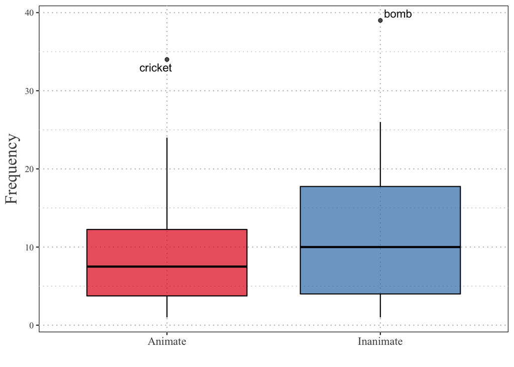

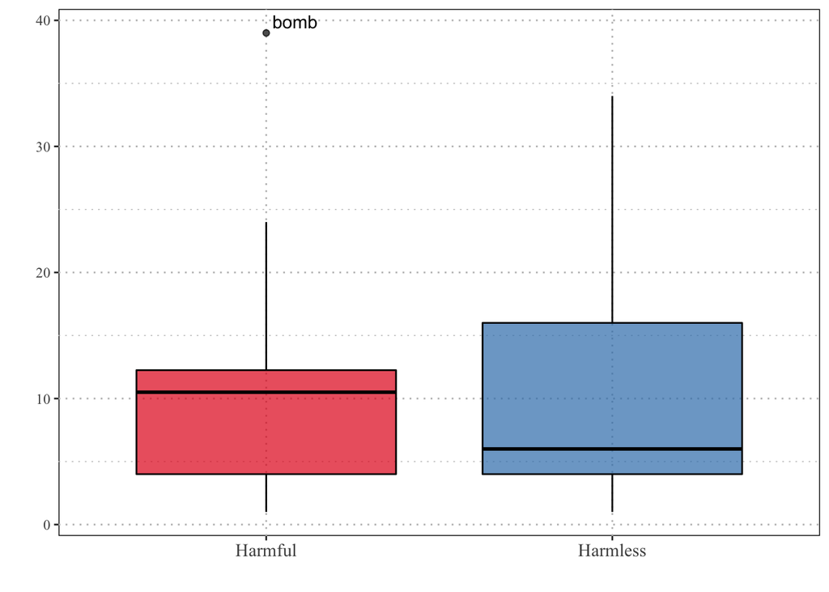

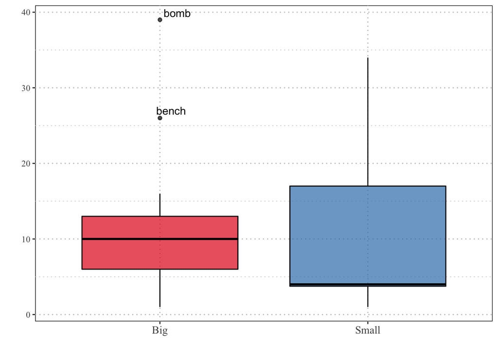

Boxplots for frequencies by experimental factor for experiment 2

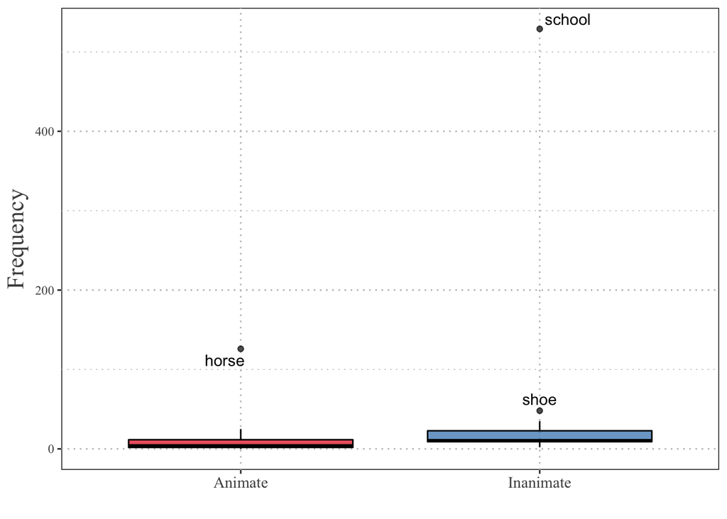

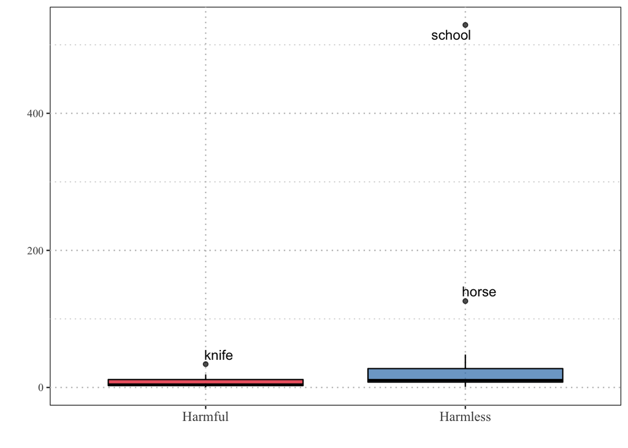

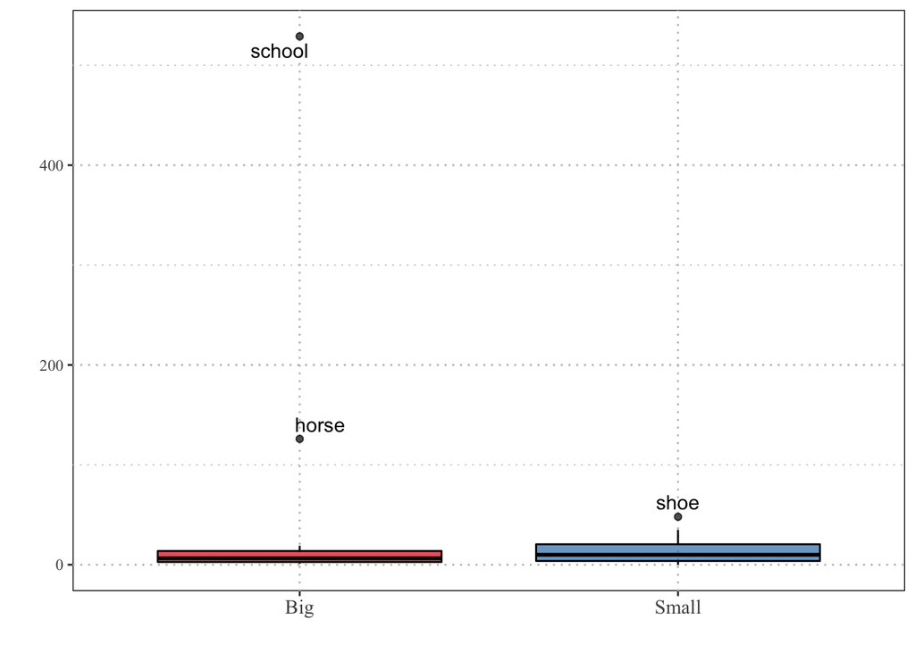

Test if there any any significant differences in word frequency across the three categories (English) Trying to rule out the possibility that any effect would be driven by word frequency

```r
library(lme4)
library(lmerTest)
library(car)

# Fit linear model
bnc_lm <- lm(data = subset(freq_bnc, Exp == 1), Freq ~ Animate * Harm * Size)
bnc_lm2 <- lm(data = subset(freq_bnc, Exp == 2), Freq ~ Animate * Harm * Size)

# Look up summaries
Anova(bnc_lm)
```

```
## Anova Table (Type II tests)
##
## Response: Freq
##                    Sum Sq Df F value Pr(>F)
## Animate             57.78  1  0.5125 0.4810
## Harm                 2.53  1  0.0225 0.8821
## Size                 5.28  1  0.0468 0.8305
## Animate:Harm         0.28  1  0.0025 0.9606
## Animate:Size       175.78  1  1.5592 0.2238
## Harm:Size           19.53  1  0.1732 0.6809
## Animate:Harm:Size   47.53  1  0.4216 0.5223
## Residuals         2705.75 24
```

```r
Anova(bnc_lm2)
```

```
## Anova Table (Type II tests)
##
## Response: Freq
##                   Sum Sq Df F value Pr(>F)
## Animate             9316  1  1.0504 0.3156
## Harm               16562  1  1.8673 0.1845
## Size                8646  1  0.9748 0.3333
## Animate:Harm        5512  1  0.6215 0.4382
## Animate:Size        2628  1  0.2963 0.5912
## Harm:Size          11552  1  1.3024 0.2650
## Animate:Harm:Size   5940  1  0.6698 0.4212
## Residuals         212868 24
```

There does not seem to be any significant difference. Let’s run the same control tests for Danish. Frequencies here are drawn from the Danish web corpus daTenTen, version 2017. For info on these corpora see: https://en.wikipedia.org/wiki/TenTen_Corpus_Family. Data have been downloaded via https://www.sketchengine.eu. As for English, values stand for lemma frequency per million words.

```r
# Read in frequency file for Danish
freq_dk <- read_tsv('freq_dk.txt')

# Add experimental information on words (both experiments)
animals_dk=c('bi', 'lam', 'rødhals', 'fårekylling', 'gås', 'tyr', 'pingvin', 'haj', 'kamel',
             'hyæne', 'reje', 'edderkop','rotte', 'loppe', 'slange', 'killing','tiger',
             'kobra', 'krokodille', 'vildsvin', 'myg', 'giftgople', 'fugleedderkop', 'skovflåt', 'giraf',
             'hest', 'delfin', 'rådyr', 'kanin' ,'sommerfugl','egern','spurv')

big_dk=c('tyr', 'hyæne', 'slange', 'haj', 'kamel', 'gås', 'lam', 'pingvin',
         'bombe', 'fængsel', 'missil', 'riffel', 'bænk', 'sofa', 'vugge', 'telt',
         'meteor', 'lavine', 'vulkan', 'bombefly', 'tiger', 'kobra', 'krokodille', 'vildsvin',
         'giraf', 'hest', 'delfin', 'rådyr' ,'skole','egetræ','kontrabas','kuppel')

harmful_dk=c('tyr', 'hyæne', 'haj', 'slange', 'bi', 'loppe', 'edderkop', 'rotte',
             'bombe', 'fængsel', 'missil', 'riffel', 'blus', 'dolk', 'nål', 'torn',
             'tiger', 'kobra', 'krokodille','vildsvin','meteor', 'lavine', 'vulkan', 'bombefly',
             'myg', 'giftgople', 'fugleedderkop', 'skovflåt', 'landmine', 'gift', 'patron', 'kniv')

dk_words_2 <- c('tiger', 'kobra', 'krokodille', 'vildsvin', 'myg', 'giftgople', 'fugleedderkop', 'skovflåt',
                'giraf', 'hest', 'delfin', 'rådyr', 'kanin', 'sommerfugl', 'egern', 'spurv',
                'meteor', 'lavine', 'vulkan', 'bombefly', 'landmine', 'gift', 'patron', 'kniv',
                'skole', 'egetræ', 'kontrabas', 'kuppel', 'krus', 'sko', 'ske', 'æble')

# Add this info to the frequency dataset
freq_dk$Animate <- ifelse(freq_dk$Word %in% animals_dk, 'Animate', 'Inanimate')
freq_dk$Size <- ifelse(freq_dk$Word %in% big_dk, 'Big', 'Small')
freq_dk$Harm <- ifelse(freq_dk$Word %in% harmful_dk, 'Harmful', 'Harmless')
# Add info on experiment number
freq_dk$Exp <- ifelse(freq_dk$Word %in% dk_words_2, 2, 1)
# Rescale frequency per million words
freq_dk$PerMillion <- freq_dk$Freq / 2570.805 # Million words in the corpus

head(freq_dk)
```

```
## # A tibble: 6 x 7
##   Word    Freq Animate   Size  Harm       Exp PerMillion
##   <chr>  <int> <chr>     <chr> <chr>    <dbl>      <dbl>
## 1 ske    17934 Inanimate Small Harmless     2       6.98
## 2 skole 857634 Inanimate Big   Harmless     2     334.
## 3 hest  261819 Animate   Big   Harmless     2     102.
## 4 gift  210613 Inanimate Small Harmful      2      81.9
## 5 sko   147290 Inanimate Small Harmless     2      57.3
## 6 æble   60392 Inanimate Small Harmless     2      23.5
```

Boxplot displaying frequency for **Danish** words, experiment 1

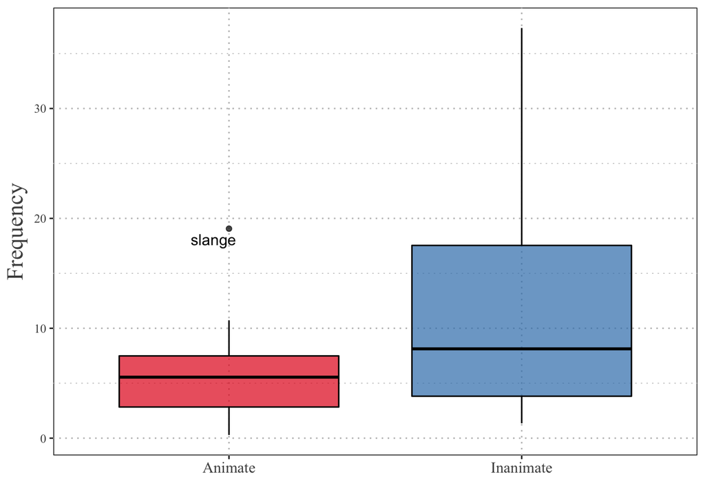

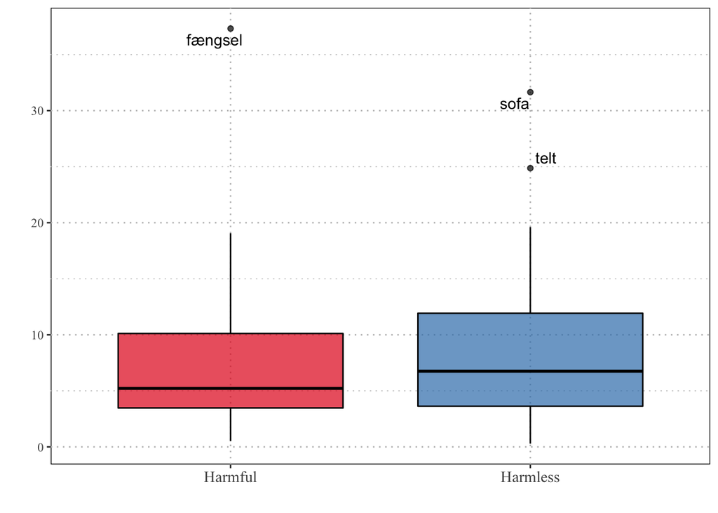

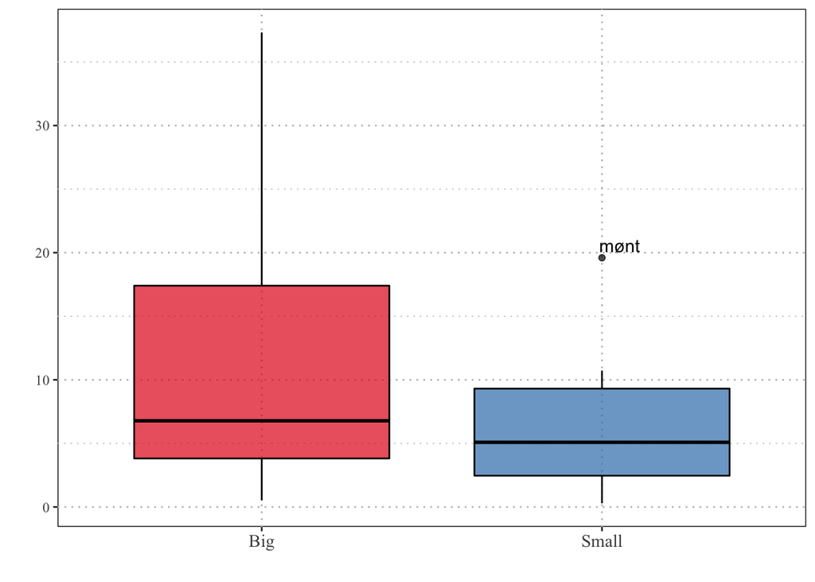

Boxplot displaying word frequency distribution for experiment 2 (Danish)

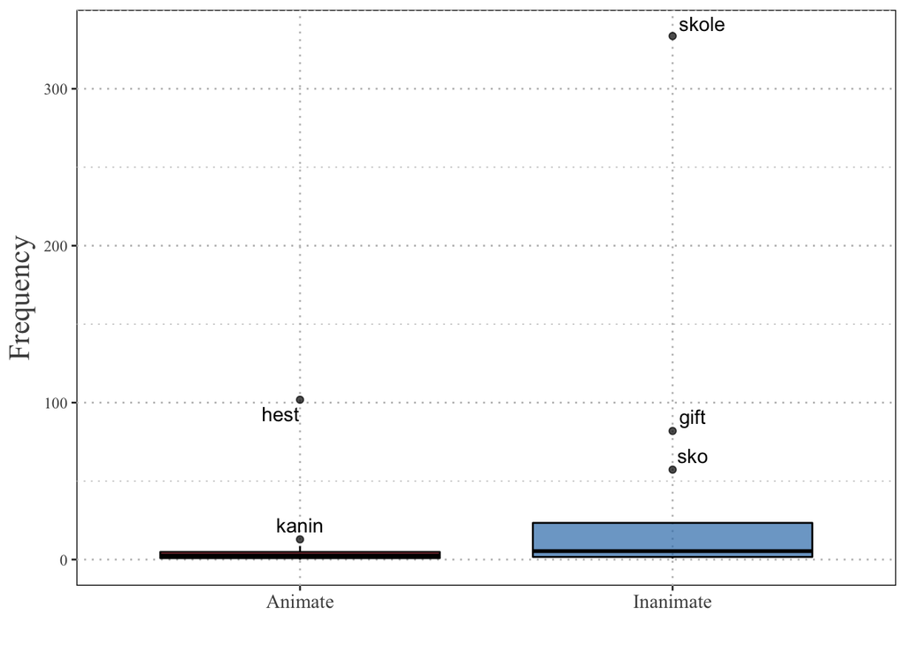

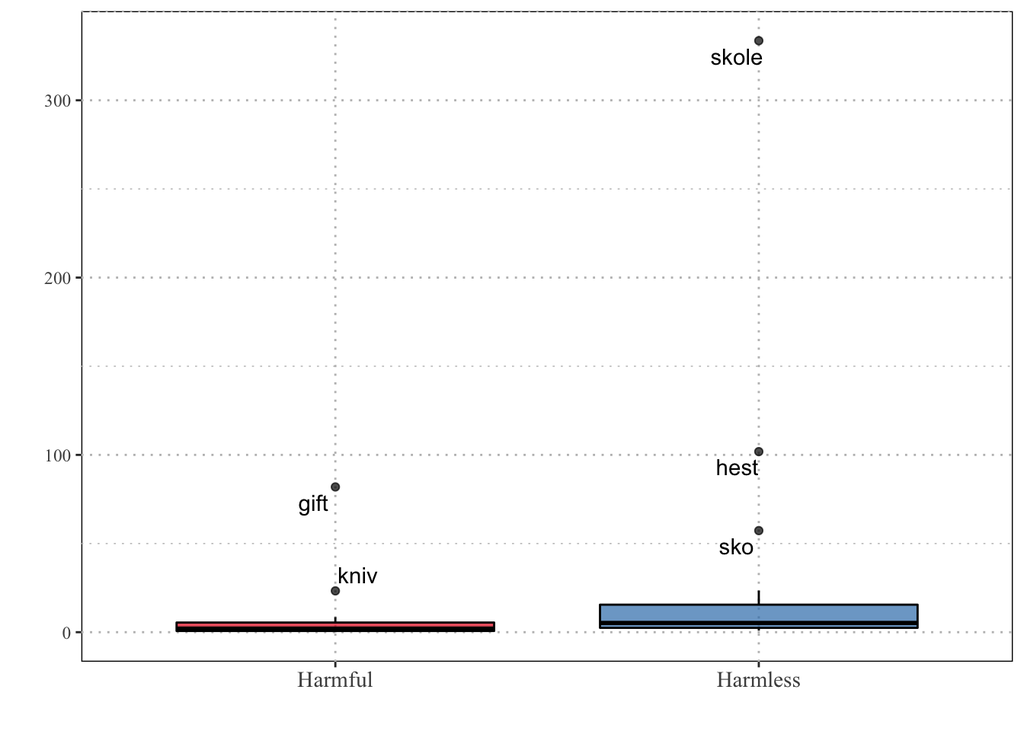

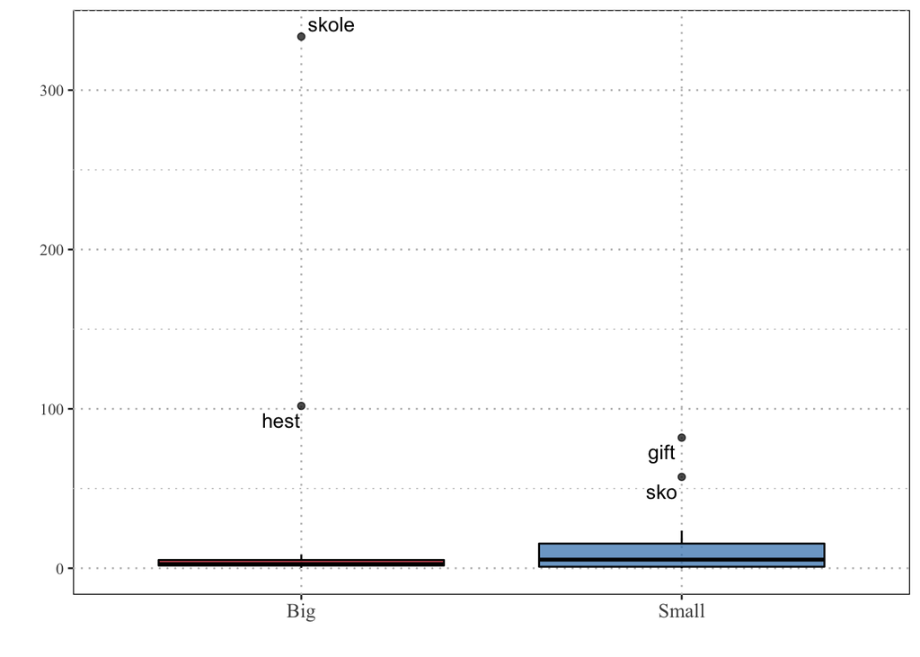

Are there any significant differences in words frequency for Danish?

```r
# Run linear regression (same FFX structure as the analyis)
dk_lm1 <- lm(data = subset(freq_dk, Exp == 1), PerMillion ~ Animate * Harm * Size)
dk_lm2 <- lm(data = subset(freq_dk, Exp == 2), PerMillion ~ Animate * Harm * Size)

# Visualize results
Anova(dk_lm1)
```

```
## Anova Table (Type II tests)
##
## Response: PerMillion
##                    Sum Sq Df F value  Pr(>F)
## Animate            318.62  1  4.7650 0.03906 *
## Harm                10.88  1  0.1627 0.69023
## Size               279.48  1  4.1796 0.05203 .
## Animate:Harm       124.76  1  1.8657 0.18463
## Animate:Size       191.78  1  2.8681 0.10329
## Harm:Size            1.70  1  0.0254 0.87463
## Animate:Harm:Size    0.07  1  0.0011 0.97361
## Residuals         1604.83 24
## ---
## Signif. codes:  0 '***' 0.001 '**' 0.01 '*' 0.05 '.' 0.1 ' ' 1
```

```r
Anova(dk_lm2)
```

```
## Anova Table (Type II tests)
##
## Response: PerMillion
##                   Sum Sq Df F value Pr(>F)
## Animate             5087  1  1.2780 0.2694
## Harm                5782  1  1.4525 0.2399
## Size                1865  1  0.4685 0.5002
## Animate:Harm        1207  1  0.3033 0.5869
## Animate:Size          83  1  0.0208 0.8864
## Harm:Size           5690  1  1.4293 0.2436
## Animate:Harm:Size   2292  1  0.5758 0.4553
## Residuals          95537 24
```

Check word frequency for Italian As for Danish, word frequencies were extracted from from the itTenTen corpus, version 2017, using https://www.sketchengine.eu. Values denote lemma frequency per million words.

```r
# Read in the frequency dataframe
freq_it <- read_tsv('freq_it.txt')

# Add info on Animacy (looks clumsy but it is correct ;) )
freq_it$Animate <- c(1,0,0,0,0,0,0,1,0,0,1,0,0,0,1,1,1,0,1,1,0,1,1,0,1,1,1,1,0,0,1,1,0,1,0,0,0,0,0,1,1,0,0,0,1,1,0,0,0,1,1,0,1,1,0,1,0,1,0,1,1,1,1,1)
# Add info on experimental words
big_it <-c('iena', 'toro', 'cammello', 'agnello', 'pinguino', 'oca','squalo', 'serpente',
           'prigione', 'panca', 'razzo', 'tenda', 'divano', 'fucile', 'culla', 'bomba' ,
           'meteorite', 'valanga', 'vulcano', 'bombardiere', 'tigre', 'cobra', 'coccodrillo', 'cinghiale',
           'giraffa', 'cavallo', 'delfino', 'cerbiatto', 'scuola', 'quercia', 'contrabbasso', 'cupola')
harm_it <-c('toro', 'iena', 'squalo', 'serpente', 'ape', 'pulce', 'ragno', 'ratto',
            'bomba', 'prigione','razzo', 'fucile', 'bruciatore', 'pugnale', 'ago', 'spina',
            'tigre', 'cobra', 'coccodrillo', 'cinghiale', 'meteorite', 'valanga', 'vulcano','bombardiere',
            'zanzara', 'medusa', 'tarantola', 'zecca', 'mina', 'veleno', 'proiettile', 'coltello')
it_words_2 <- c('tigre', 'cobra', 'coccodrillo', 'cinghiale', 'zanzara', 'medusa', 'tarantola', 'zecca',
                'giraffa', 'cavallo', 'delfino', 'cerbiatto', 'coniglio', 'farfalla', 'scoiattolo', 'passero',
                'meteorite', 'valanga', 'vulcano', 'bombardiere', 'mina', 'veleno', 'proiettile', 'coltello',
                'scuola', 'quercia', 'contrabbasso', 'cupola', 'tazza', 'scarpa', 'cucchiaio', 'mela')

# Add info on experimental factors per word to the dataframe
freq_it$Animate <- ifelse(freq_it$Animate == 1, 'Animate', 'Inanimate')
freq_it$Size <- ifelse(freq_it$Word %in% big_it, 'Big', 'Small')
freq_it$Harm <- ifelse(freq_it$Word %in% harm_it, 'Harmful', 'Harmless')
# Add info on experiment number and convert raw frequencies to frequency per million words
freq_it$Exp <- ifelse(freq_it$Word %in% it_words_2, 2, 1)
freq_it$PerMillion <- freq_it$Freq / 5864.496 #Million words in the corpus
```

Plot frequencies for experiment 1, **Italian**

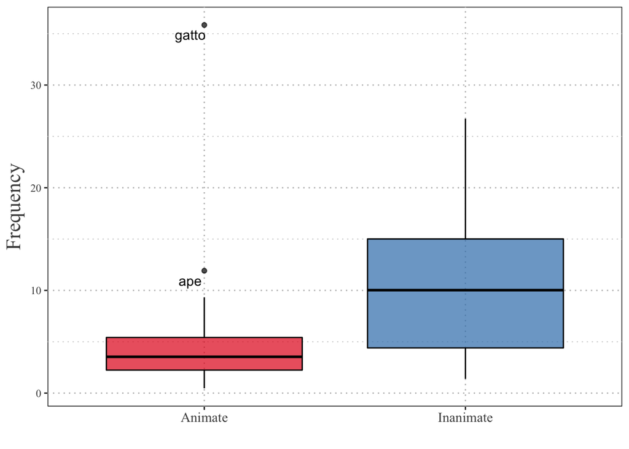

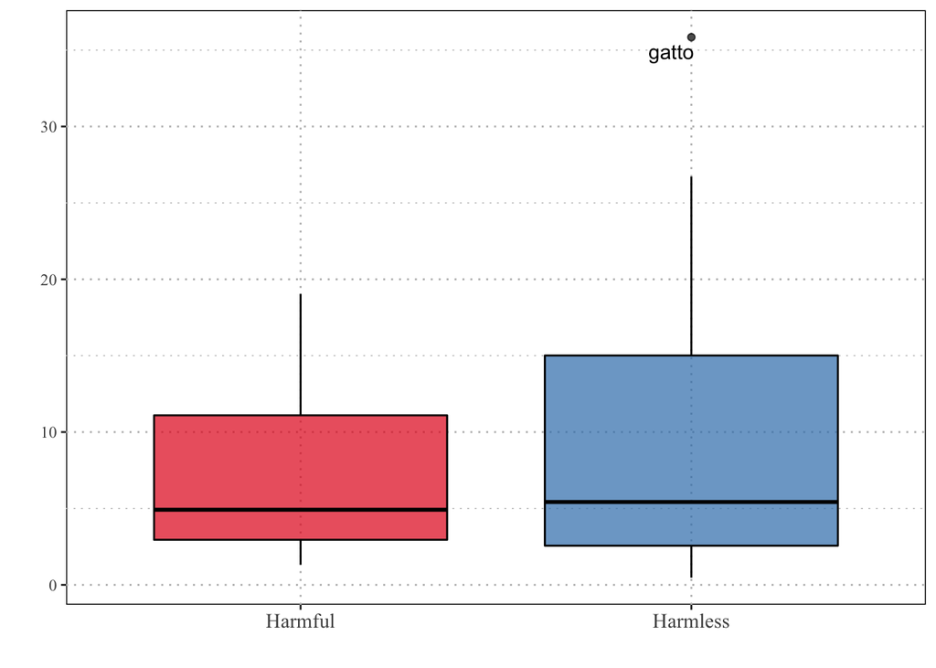

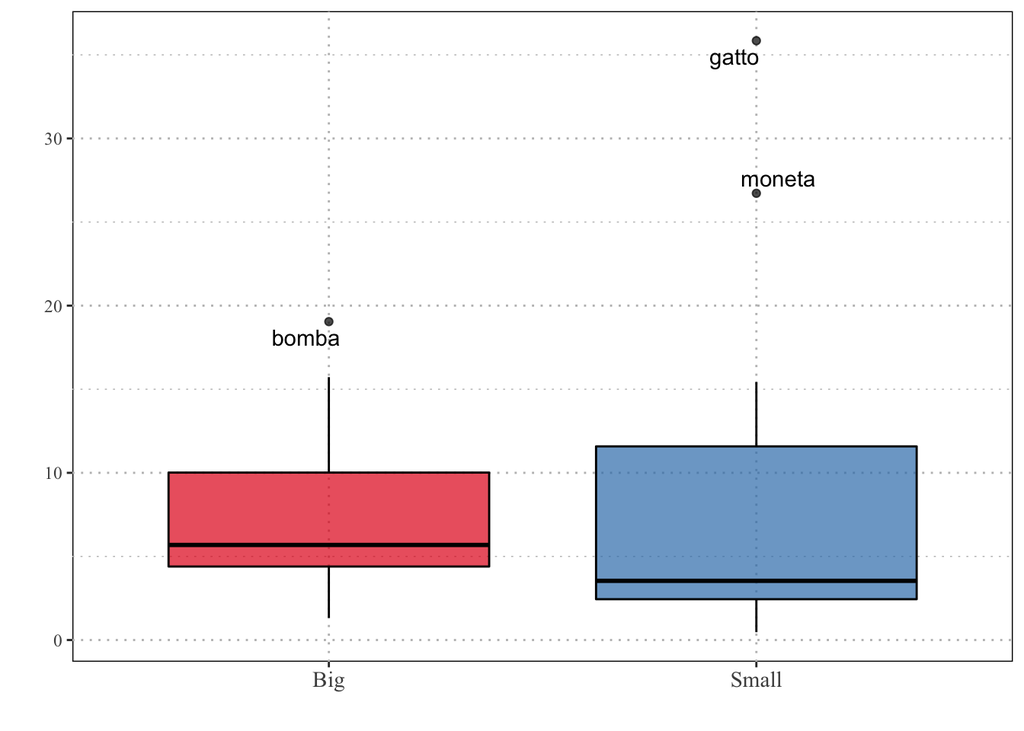

Plot word frequency for experiment 2

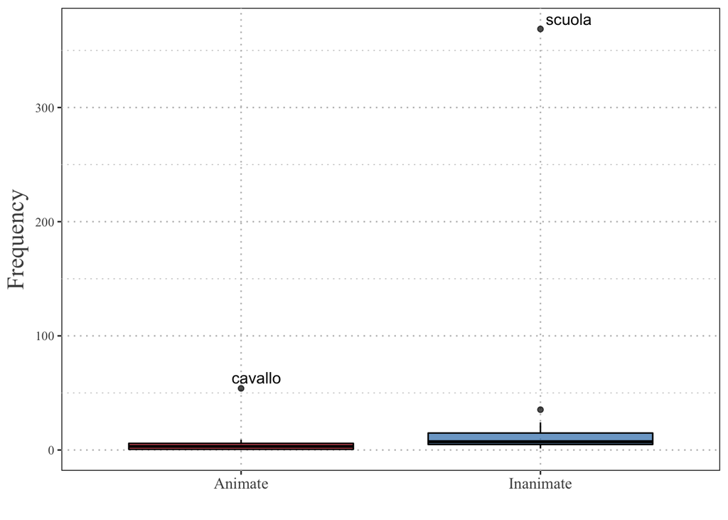

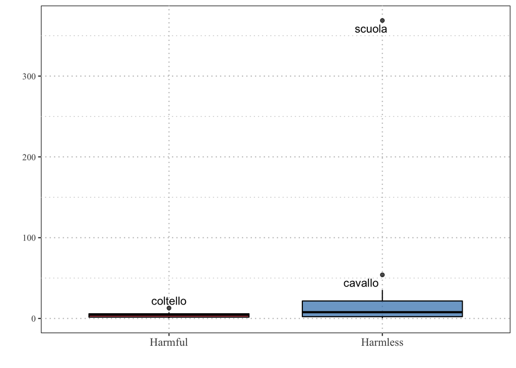

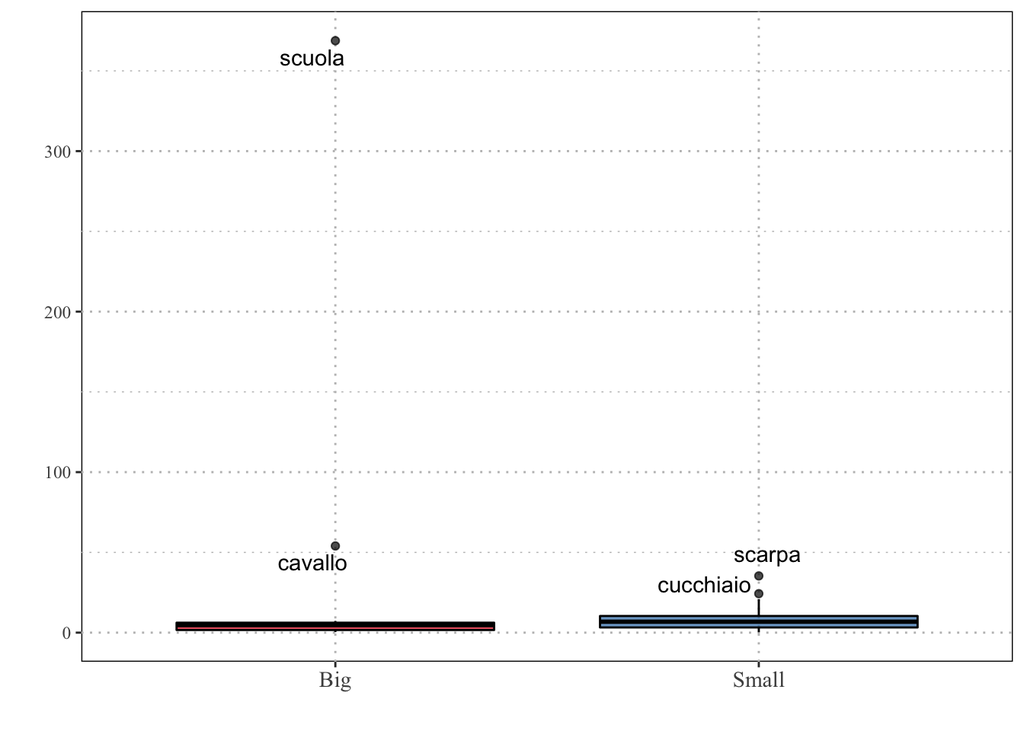

Run statistical model to check for differences in frequency across experimental factors

```r
# Estimate linear regression model
it_lm1 <- lm(data = subset(freq_it, Exp == 1), PerMillion ~ Animate * Harm * Size)
it_lm2 <- lm(data = subset(freq_it, Exp == 2), PerMillion ~ Animate * Harm * Size)

# Visualize results
Anova(it_lm1)
```

```
## Anova Table (Type II tests)
##
## Response: PerMillion
##                    Sum Sq Df F value Pr(>F)
## Animate            140.55  1  2.1062 0.1597
## Harm                51.51  1  0.7719 0.3883
## Size                11.75  1  0.1761 0.6784
## Animate:Harm         4.43  1  0.0665 0.7988
## Animate:Size        38.11  1  0.5711 0.4572
## Harm:Size           90.04  1  1.3493 0.2568
## Animate:Harm:Size    0.43  1  0.0064 0.9370
## Residuals         1601.54 24
```

```r
Anova(it_lm2)
```

```
## Anova Table (Type II tests)
##
## Response: PerMillion
##                   Sum Sq Df F value Pr(>F)
## Animate             5388  1  1.2701 0.2709
## Harm                7264  1  1.7124 0.2031
## Size                3230  1  0.7615 0.3915
## Animate:Harm        4373  1  1.0309 0.3201
## Animate:Size        1749  1  0.4123 0.5269
## Harm:Size           3743  1  0.8822 0.3569
## Animate:Harm:Size   2301  1  0.5425 0.4686
## Residuals         101810 24
```

### Crosslinguistic differences word-by-word

X and y axis display **proportion of distal demonstratives** (more intuitive)

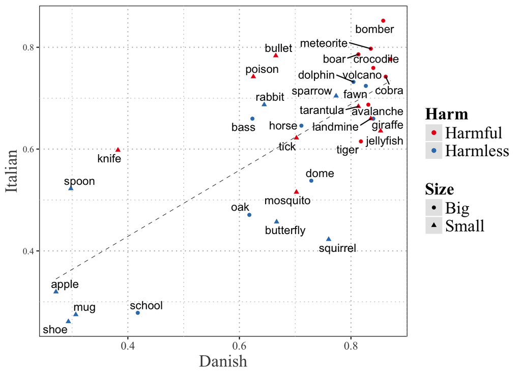

```r
# Experiment 2
Lang_summ <- subset(data_all, !(ExpNr == 1 & Lang == 'IT')) %>% group_by(Lang, ExpNr, NounEng, Animate, Size, Harm, Demonstrative) %>% summarize(count = n()) %>% mutate(PropProximal = count / sum(count))
Lang_summ <- subset(Lang_summ, Demonstrative == 'proximal')

Lang_summ_DK <- subset(Lang_summ, ExpNr == 2 & Lang == 'DK')
Lang_summ_IT <- subset(Lang_summ, ExpNr == 2 & Lang == 'IT')
Lang_summ2 <- cbind(Lang_summ_DK, Lang_summ_IT)[, c(1:9,18)]
colnames(Lang_summ2)[10] <- 'PropProxITA'

p1 <- ggplot(data = subset(Lang_summ2), aes(y = 1 - PropProxITA , x = 1 - PropProximal)) + geom_point(aes(color = Harm, shape = Size)) + geom_smooth(method='lm', color = 'black', size = 0.2,  se = F, linetype = 'dashed') + xlab('Danish') + ylab('Italian') + scale_color_brewer(palette = 'Set1')+
  theme(panel.background = element_rect(fill='white', color = 'black'),
        panel.grid.major = element_line(color = 'grey', linetype = 'dotted'),
        panel.grid.minor = element_line(color = 'grey', linetype = 'dotted')) +
  geom_text_repel(aes(label = NounEng))

# Same for English
Lang_summ_EN1 <- subset(Lang_summ, ExpNr == 1 & Lang == 'EN')
Lang_summ_DK1 <- subset(Lang_summ, ExpNr == 1 & Lang == 'DK')
Lang_summ1 <- cbind(Lang_summ_DK1, Lang_summ_EN1)[, c(1:9,18)]
colnames(Lang_summ1)[10] <- 'PropProxEN'

p2 <- ggplot(data = subset(Lang_summ1), aes(y = 1 - PropProxEN , x = 1- PropProximal)) + geom_point(aes(color = Harm, shape = Size)) +
  geom_smooth(method='lm', color = 'black', size = 0.2,  se = F, linetype = 'dashed', fullrange = TRUE) +
  xlab('Danish') + ylab('English')+ scale_color_brewer(palette = 'Set1')+
  theme(panel.background = element_rect(fill='white', color = 'black'),
        panel.grid.major = element_line(color = 'grey', linetype = 'dotted'),
        panel.grid.minor = element_line(color = 'grey', linetype = 'dotted')) +
  geom_text_repel(aes(label = NounEng))

p1
```

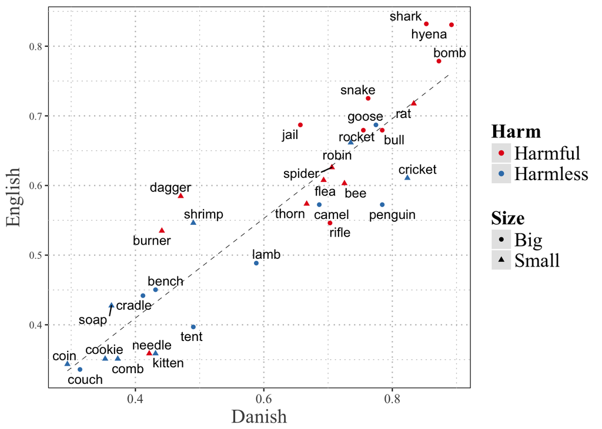

```r
p2
```